# 2019202265-贾耀博-第二周作业

# 问题1

## 1.1 附录A中的题

### 1.1.1

**试用二分法及R程序求一下方成在$(-10,10)之间的根$**

**$$2x^3-4x^2+3x-6=0$$**

分析：三次方程一般而言有三个实根，需要于是在二分法过程中可能出现分支，需要先存储这些分支然后逐个用二分法求解

```r
# 定义方程
eq<-function(x){
  return (2*x^3-4*x^2+3*x-6)
}

# 定义精度
eps <- 0.01

# 存储结果
ans<-c()

# 主函数
solution <- function(l, r){
  fl<-eq(l)
  fr<-eq(r)
  if(fl*fr>0){
      return
  }else{
      m <- (l+r)/2
    if(abs(eq(m))<eps){# 是根
        print(m)
        return
    }
    if(abs(fr-fl)>eps){
      # 递归
      solution(l,m)
      solution(m,r)
    }
  }
}

solution(-10,10)
```

```
## [1] 1.999512
## [1] 2.000732
## [1] 2.000122
## [1] 1.999817
```

```
## .Primitive("return")
```

可以得到该方程在$(-10,10)$的一个实根为2

### 1.1.2

**从0到$2\pi$,每隔0.2，求解下列函数的值**

**$$\frac{sin(x)}{cos(x)+x}$$**

```r
# 从0到2pi,每隔0.2
x<-seq(0,2*pi,by=0.2)

# 定义函数
fun<-function (x){
  return (sin(x)/(cos(x)+x))
}

#求值
fun(x)
```

```
##  [1]  0.00000000  0.16835434  0.29477696  0.39614703  0.47928969  0.54630249
##  [7]  0.59655932  0.62768812  0.63634664  0.61918167  0.57410463  0.50170460
## [13]  0.40626767  0.29573636  0.18031660  0.07020870 -0.02651315 -0.10502257
## [19] -0.16369992 -0.20334042 -0.22615717 -0.23494260 -0.23251392 -0.22141818
## [25] -0.20381889 -0.18148857 -0.15585288 -0.12805366 -0.09901343 -0.06949380
## [31] -0.04014492 -0.01154574
```

### 1.1.3

**CCB编码问题：将26个字母的前13个转换成其后的第13个字母，并互换大小写，后13个转换成其后的第13个字母，并互换大小写。非字母字符不变，试用R程序帮助发报人实现上述转换**

```r
# a的ascii为97，A的ascii为65，相差32

asc <- function(x) { strtoi(charToRaw(x),16L) }
chr <- function(n) { rawToChar(as.raw(n)) }

ccb<-function(x){
  answer <-c()
  v<-unlist(strsplit(x, split = ""))
  print(v)
  for (c in seq_along(v)){
    u2i <- asc(v[c])
    if (u2i>=65&&u2i<=77){ # 大写前十三
      u<-u2i+32+13
    }else if(u2i>=78&&u2i<=90){ # 大写后十三
      u<-u2i+32-13
    }else if(u2i>=97&&u2i<=109){ #小写前十三
      u<-u2i-32+13
    }else if(u2i>=110&&u2i<=122){ #小写后十三
      u<-u2i-32-13
    }
    print(chr(u))
    answer<-c(answer,chr(u))
 }
  return (answer)
}

ccb("People")
```

```
## [1] "P" "e" "o" "p" "l" "e"
## [1] "c"
## [1] "R"
## [1] "B"
## [1] "C"
## [1] "Y"
## [1] "R"
```

```
## [1] "c" "R" "B" "C" "Y" "R"
```

### 1.1.4

**13个人围成一个圈，从第一个人开始顺序报号1，2，3，报到3者退出圈子，找出最后留在圈子中原来人的位置**

```r
pp<-1:13;
bgn<-1
while(length(pp)>1){
  print(pp)
  d<-(bgn+2)%%length(pp)
  index<-c(d)
  pp<-pp[-index]
  bgn<-d
}
```

```
##  [1]  1  2  3  4  5  6  7  8  9 10 11 12 13
##  [1]  1  2  4  5  6  7  8  9 10 11 12 13
##  [1]  1  2  4  5  7  8  9 10 11 12 13
##  [1]  1  2  4  5  7  8 10 11 12 13
## [1]  1  2  4  5  7  8 10 11 13
## [1]  1  4  5  7  8 10 11 13
## [1]  1  4  5  8 10 11 13
## [1]  1  4  5  8 10 13
## [1]  1  5  8 10 13
## [1]  1  5  8 13
## [1]  1  8 13
## [1]  8 13
```

```r
print(pp)
```

```
## [1] 13
```

可以看出最后剩下的是原来的第13位

# 1.2 John 书上题

## 1.2.1

**A sunflower plot can be useful for visualizing the relationship between two numeric variables which are either discrete or have been rounded. Use the R function sunflowerplot to obtain a sunflower plot of the relationship between height and weight for the baseball data in Rfit**

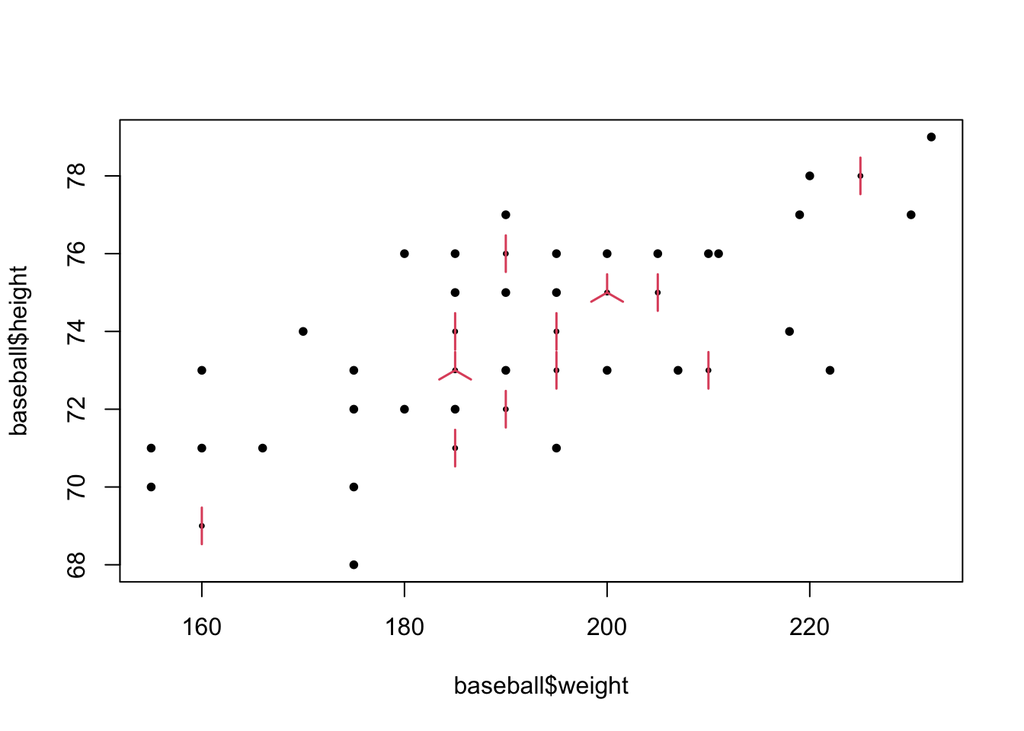

```r
library(Rfit)
data(baseball)
sunflowerplot(baseball$weight, baseball$height)
```

## 1.2.2

**A diagnostic test of clairvoyance is to declare a person clairvoyant if they get 8 or more tosses of a fair coin correct out of 10. Determine, either via simulation or directly, the specificity of the test. That is, in this case, determine the probability that a person who is guessing is correctly classified as non-clairvoyant**

```r
# 试验次数
N<-10000


pos<-c()

#模拟抽样
for (i in 1:N){
  samp<-sample(0:1,10, replace = TRUE)
  pos<-c(pos,sum(samp))
}
pos<-pos[pos>=8]

length(pos)/N
```

```
## [1] 0.0581
```

## 1.2.3

**Approximate the power of a t-test of $H_0:\mu=0$ versus $H_A$ : $\mu >0$ when the true mean is $\mu$ = 0.5. Assume a random sample of size n = 25 from a normal distribution with $\sigma$ = 1. Assume $\alpha$ = 0.05**

```r
X<-matrix(rnorm(100*25,mean = 0.5, sd=1),ncol = 100)
myttest <- function (data) t.test(data)$p.value
pval<-apply(X,1,myttest)

# 取这100次试验pval小于0.05的均值，也就是显著频率
mean(pval<0.05)
```

```
## [1] 1
```

## 1.2.4

**Use the commands dnorm, seq, and lines to create a plot of the pdf of a normal distribution with $\mu$ = 50 and $\sigma^2$ = 10**

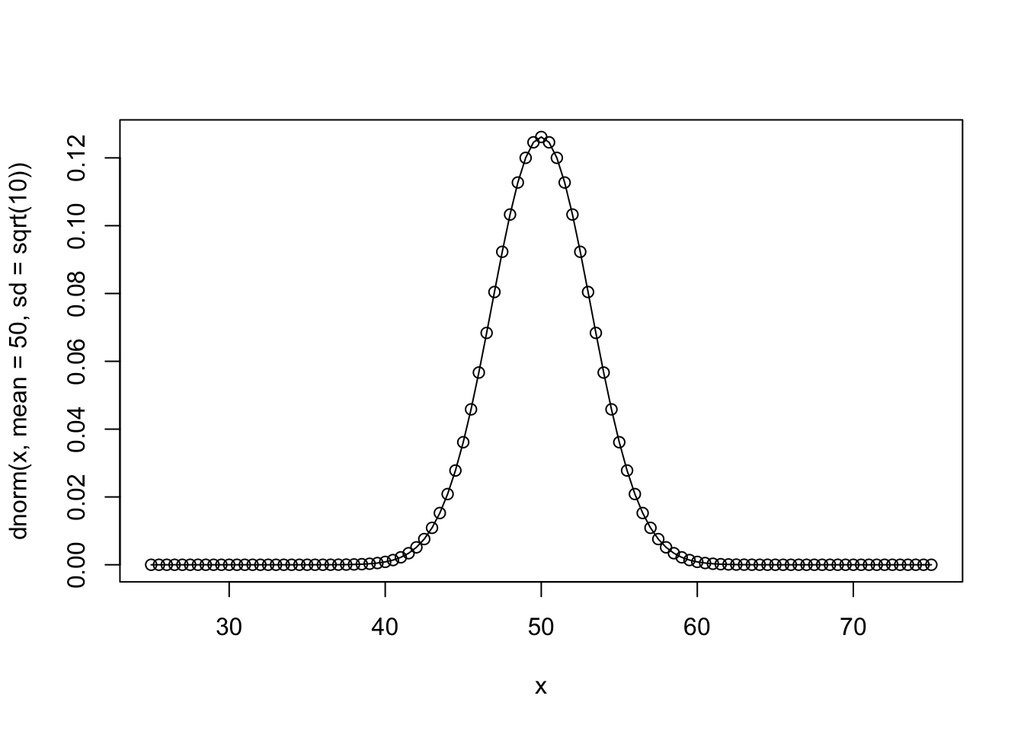

```r
x<-seq(25,75,by=0.5)
plot(x,dnorm(x, mean=50, sd=sqrt(10)))
lines(x,dnorm(x,mean=50, sd=sqrt(10)))
```

# 问题2

## 2.1

**将数据导入RStudio，转换成data.frame 形式**

```r
library(tidyverse)
library(dplyr)
dt<-read.csv("/Users/jiayaobo/PycharmProjects/nonparams/homework1/protein.csv" )
head(dt)
```

```
##          Country RedMeat WhiteMeat Eggs Milk Fish Cereals Starch Nuts FrandVeg
## 1        Albania    10.1       1.4  0.5  8.9  0.2    42.3    0.6  5.5      1.7
## 2        Austria     8.9      14.0  4.3 19.9  2.1    28.0    3.6  1.3      4.3
## 3        Belgium    13.5       9.3  4.1 17.5  4.5    26.6    5.7  2.1      4.0
## 4       Bulgaria     7.8       6.0  1.6  8.3  1.2    56.7    1.1  3.7      4.2
## 5 Czechoslovakia     9.7      11.4  2.8 12.5  2.0    34.3    5.0  1.1      4.0
## 6        Denmark    10.6      10.8  3.7 25.0  9.9    21.9    4.8  0.7      2.4
##   聚类      距离
## 1    1 14.736648
## 2    5  7.802416
## 3    5  2.210961
## 4    1  6.882513
## 5    2 11.950846
## 6    3  4.831054
```

## 2.2

**选择两个变量Egg和Fish，分别计算25个国家在这两种食物上的基本摄入量，至少有均值、方差、最大值和最小值、中位数等基本统计量**

```r
mean(dt$Eggs)
```

```
## [1] 2.936
```

```r
var(dt$Eggs)
```

```
## [1] 1.249067
```

```r
max(dt$Eggs)
```

```
## [1] 4.7
```

```r
min(dt$Eggs)
```

```
## [1] 0.5
```

```r
median(dt$Eggs)
```

```
## [1] 2.9
```

```r
mean(dt$Fish)
```

```
## [1] 4.284
```

```r
var(dt$Fish)
```

```
## [1] 11.57723
```

```r
max(dt$Fish)
```

```
## [1] 14.2
```

```r
min(dt$Fish)
```

```
## [1] 0.2
```

```r
median(dt$Fish)
```

```
## [1] 3.4
```

F的均值为4.284，方差为11.57723,最大值为14.2，最小值为0.2，中位数为3.4

## 2.3

**做散点图，观察两个变量之间的关系**

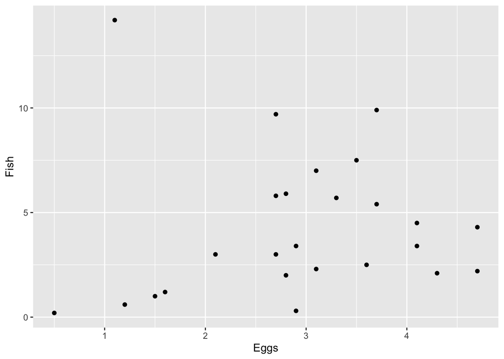

```r
dt %>% ggplot()+
        geom_point(aes(x=Eggs,y=Fish))
```

## 2.4

**这两个变量如果服从二元正态分布，请给出这个正态分布的均值向量$\mu=(\mu_E,\mu_F)^t$ 和协方差矩阵的矩估计$\Sigma=(\sigma^2_E,\sigma^2_F,\sigma_{EF},\rho)$,请给出具体的估计**

均值向量的矩估计就是Eggs和Fish两变量各自的均值组成的向量，因此

$$\mu=(2.936,4.284)^t$$

而对协方差矩阵进行矩估计，$\sigma^2_E$和$\sigma^2_F$的矩估计是各自样本方差，而$\sigma_{EF}$的矩估计为样本协方差，$\rho$的矩估计为样本相关系数

下面计算相关系数和协方差

```r
# 协方差
cov(dt$Eggs,dt$Fish)
```

```
## [1] 0.24935
```

```r
#相关系数
cor(dt$Fish,dt$Eggs)
```

```
## [1] 0.06557136
```

于是得到协方差矩阵的矩估计

$$\Sigma=(1.249067, 11.57723,0.24935,0.06557136)$$

## 2.5

**如果想用这两个变量预测第三个变量WhiteMeat，用三元正态分布去表示$\mu_{W|E,F}和\Sigma_{W|E,F}$, 请给出具体的估计**

首先计算有关W的统计量

```r
mean(dt$WhiteMeat)
```

```
## [1] 7.896
```

```r
var(dt$WhiteMeat)
```

```
## [1] 13.64623
```

得到W的均值为7.896,方差为13.64623。

根据矩估计的方法可以得到均值向量$\mu_{W|E,F}=(2.936,4.284,7.896)^t$

为了得到协方差矩阵还需要知道两两间的协方差和相关系数

```r
cov(dt$WhiteMeat, dt$Eggs)
```

```
## [1] 2.5614
```

```r
cor(dt$WhiteMeat,dt$Eggs)
```

```
## [1] 0.6204092
```

得到$\sigma_{EW}=2.5614$,以及$\rho_{EW}=0.6204092$

```r
cov(dt$WhiteMeat, dt$Fish)
```

```
## [1] -2.941317
```

```r
cor(dt$WhiteMeat,dt$Fish)
```

```
## [1] -0.2340092
```

得到$\sigma_{FW}=-2.941317$,以及$\rho_{FW}=-0.2340092$

最终得到

$$\begin{align}\Sigma_{W|E,F} & =(\sigma^2_{EF},\sigma^2_{EW},\sigma^2_{FW},\sigma_{EF},\sigma_{EW},\sigma_{FW},\rho_{EF},\rho_{EW},\rho_{FW})\\ &= (1.25,11.58,13.65,0.25,2.56,-2.94,0.07,0.62,-0.23)\end{align}$$

## 2.6

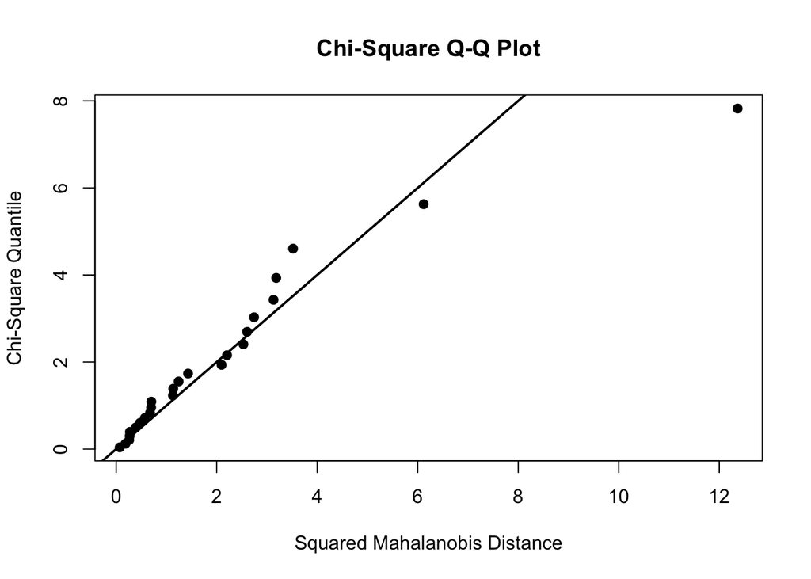

```
## $multivariateNormality
##             Test        E df   p value MVN
## 1 Doornik-Hansen 7.604596  4 0.1071845 YES
##
## $univariateNormality
##               Test  Variable Statistic   p value Normality
## 1 Anderson-Darling     E        0.3929    0.3508    YES
## 2 Anderson-Darling     F        0.7257    0.0509    YES
##
## $Descriptives
##    n  Mean  Std.Dev Median Min  Max 25th 75th       Skew   Kurtosis
## E 25 2.936 1.117617    2.9 0.5  4.7  2.7  3.7 -0.3942684 -0.6646212
## F 25 4.284 3.402533    3.4 0.2 14.2  2.1  5.8  1.0963253  0.7974802
```

```r
# 使用了mvn包
library(MVN)
dt_ef<-data.frame(E=dt$Eggs,F=dt$Fish)
mvn(dt_ef,mvnTest = c("dh"), multivariatePlot = "qq")
```

从QQ图上看，E和F较为符合二元正态分布，并且根据Doornik-Hansen检验，p=0.107184>0.05

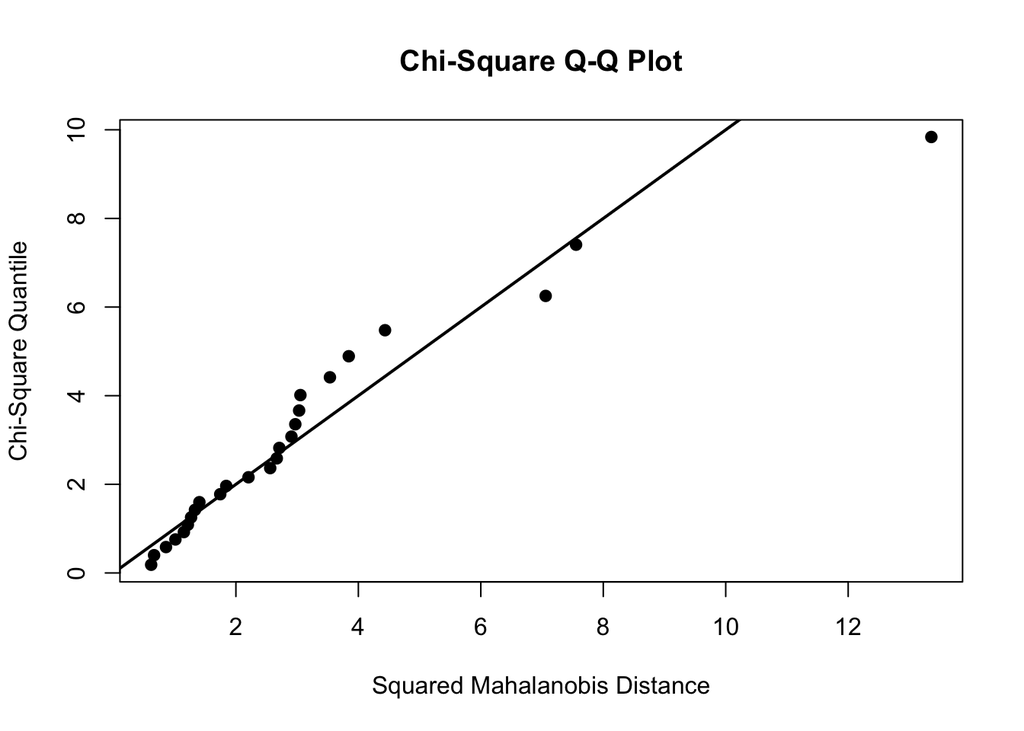

```
## $multivariateNormality
##             Test        E df    p value MVN
## 1 Doornik-Hansen 11.28836  6 0.07986271 YES
##
## $univariateNormality
##               Test  Variable Statistic   p value Normality
## 1 Anderson-Darling     E        0.3929    0.3508    YES
## 2 Anderson-Darling     F        0.7257    0.0509    YES
## 3 Anderson-Darling     W        0.6238    0.0926    YES
##
## $Descriptives
##    n  Mean  Std.Dev Median Min  Max 25th 75th        Skew   Kurtosis
## E 25 2.936 1.117617    2.9 0.5  4.7  2.7  3.7 -0.39426844 -0.6646212
## F 25 4.284 3.402533    3.4 0.2 14.2  2.1  5.8  1.09632534  0.7974802
## W 25 7.896 3.694081    7.8 1.4 14.0  4.9 10.8  0.03504453 -1.4190709
```

```r
dt_efw<-data.frame(E=dt$Eggs,F=dt$Fish,W=dt$WhiteMeat)
mvn(dt_efw,mvnTest = c("dh"), multivariatePlot = "qq")
```

从QQ图上看，E、F和W较为符合三元正态分布，并且根据Doornik-Hansen检验，p=0.07986271>0.05

综上所述，从而之前的正态性假设较为合理